# Peer Assessment 1 - Reproducible Research by Robert Carreras-Torres

## Data

The variables included in this dataset are: - steps: Number of steps taking in a 5-minute interval (missing values are coded as NA) - date: The date on which the measurement was taken in YYYY-MM-DD format - interval: Identifier for the 5-minute interval in which measurement was taken

## Loading and preprocessing the data

```r
setwd("/media/robert/UDISK/RepoResearch")
activity <- read.csv("activity.csv")
library(plyr)
library(ggplot2)
library(memisc)
```

## What is mean total number of steps taken per day?

Histogram of the total number of steps taken each day ingoring missing data

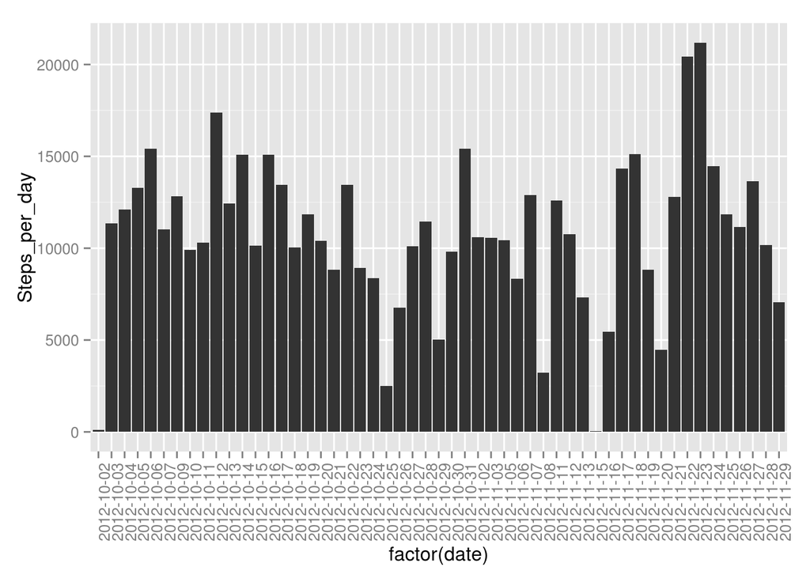

```r
Activity <- activity[!is.na(activity$steps),]
Total_steps_day <- ddply(Activity, ~date, summarize, Steps_per_day = sum(steps))
stepsday_plot <- ggplot(Total_steps_day, aes(x=factor(date),y=Steps_per_day))
stepsday_plot + geom_bar(stat ="identity") + theme(axis.text.x = element_text(angle = 90, hjust = 1))
```

Mean and median of the total number of steps taken per day

```r
MM_steps_day <- ddply(Activity, ~date, summarize, Mean_steps_per_day = mean(steps), Median_stpes_per_day = median(steps))
MM_steps_day
```

```
##          date Mean_steps_per_day Median_stpes_per_day
## 1  2012-10-02          0.4375000                    0
## 2  2012-10-03         39.4166667                    0
## 3  2012-10-04         42.0694444                    0
## 4  2012-10-05         46.1597222                    0
## 5  2012-10-06         53.5416667                    0
## 6  2012-10-07         38.2465278                    0
## 7  2012-10-09         44.4826389                    0
## 8  2012-10-10         34.3750000                    0
## 9  2012-10-11         35.7777778                    0
## 10 2012-10-12         60.3541667                    0
## 11 2012-10-13         43.1458333                    0
## 12 2012-10-14         52.4236111                    0
## 13 2012-10-15         35.2048611                    0
## 14 2012-10-16         52.3750000                    0
```

[output cut: 39 more lines]

## What is the average daily activity pattern?

Time series plot of the 5-minute interval (x-axis) and the average number of steps taken, averaged across all days (y-axis)

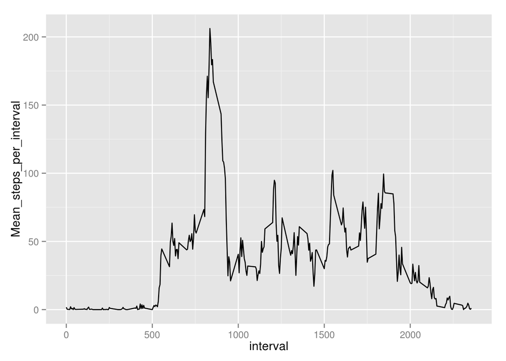

```r
Mean_steps_interval <- ddply(Activity, ~interval, summarize, Mean_steps_per_interval = mean(steps))
stepsinterval_plot <- ggplot(Mean_steps_interval, aes(x=interval, y=Mean_steps_per_interval))
stepsinterval_plot + geom_line(stat ="identity")
```

Which 5-minute interval, on average across all the days in the dataset, contains the maximum number of steps?

```r
Mean_steps_interval[which.max(Mean_steps_interval$Mean_steps_per_interval),"interval"]
```

```
## [1] 835
```

## Imputing missing values

Total number of missing values in the dataset

```r
sum(is.na(activity$steps))
```

```
## [1] 2304
```

New dataset with the missing data filled in

```r
activity_imp <- activity
for (i in 1:length(activity_imp$steps)){
  if (is.na(activity_imp[i,"steps"])){
    interval <- activity_imp[i,"interval"]
    activity_imp[i,"steps"] <- Mean_steps_interval[Mean_steps_interval$interval == interval, "Mean_steps_per_interval"]
  }
}
```

Histogram of the total number of steps taken each day

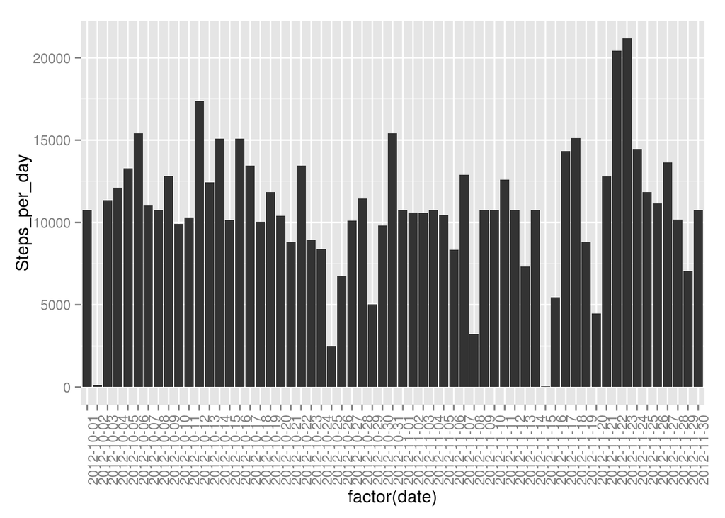

```r
Total_imp_steps_day <- ddply(activity_imp, ~date, summarize, Steps_per_day = sum(steps))
imp_stepsday_plot <- ggplot(Total_imp_steps_day, aes(x=factor(date),y=Steps_per_day))
imp_stepsday_plot + geom_bar(stat ="identity") + theme(axis.text.x = element_text(angle = 90, hjust = 1))
```

Mean and median total number of steps taken per day.

```r
MM_imp_steps_day <- ddply(activity_imp, ~date, summarize, Mean_imp_steps_per_day = mean(steps), Median_imp_stpes_per_day = median(steps))
MM_imp_steps_day
```

```
##          date Mean_imp_steps_per_day Median_imp_stpes_per_day
## 1  2012-10-01             37.3825996                 34.11321
## 2  2012-10-02              0.4375000                  0.00000
## 3  2012-10-03             39.4166667                  0.00000
## 4  2012-10-04             42.0694444                  0.00000
## 5  2012-10-05             46.1597222                  0.00000
## 6  2012-10-06             53.5416667                  0.00000
## 7  2012-10-07             38.2465278                  0.00000
## 8  2012-10-08             37.3825996                 34.11321
## 9  2012-10-09             44.4826389                  0.00000
## 10 2012-10-10             34.3750000                  0.00000
## 11 2012-10-11             35.7777778                  0.00000
## 12 2012-10-12             60.3541667                  0.00000
## 13 2012-10-13             43.1458333                  0.00000
## 14 2012-10-14             52.4236111                  0.00000
```

[output cut: 47 more lines]

Using the mean per interval to impute the missing data strongly afffects the meadian of the days without observed data. This points out that most probably the median is more apropiated as imputation strategy.

## Are there differences in activity patterns between weekdays and weekends?

New factor variable in the dataset with two levels – “weekday” and “weekend” indicating whether a given date is a weekday or weekend day.

```r
activity_imp$weekdays <- weekdays(as.POSIXct(activity_imp$date))
activity_imp$weekday_type <- recode(activity_imp$weekdays, "weekday" <- c("Monday","Tuesday","Wednesday","Thursday","Friday"), "weekend" <- c("Saturday","Sunday"), otherwise="copy")
```

Time series plot (i.e. type = “l”) of the 5-minute interval (x-axis) and the average number of steps taken, averaged across all weekday days or weekend days (y-axis).

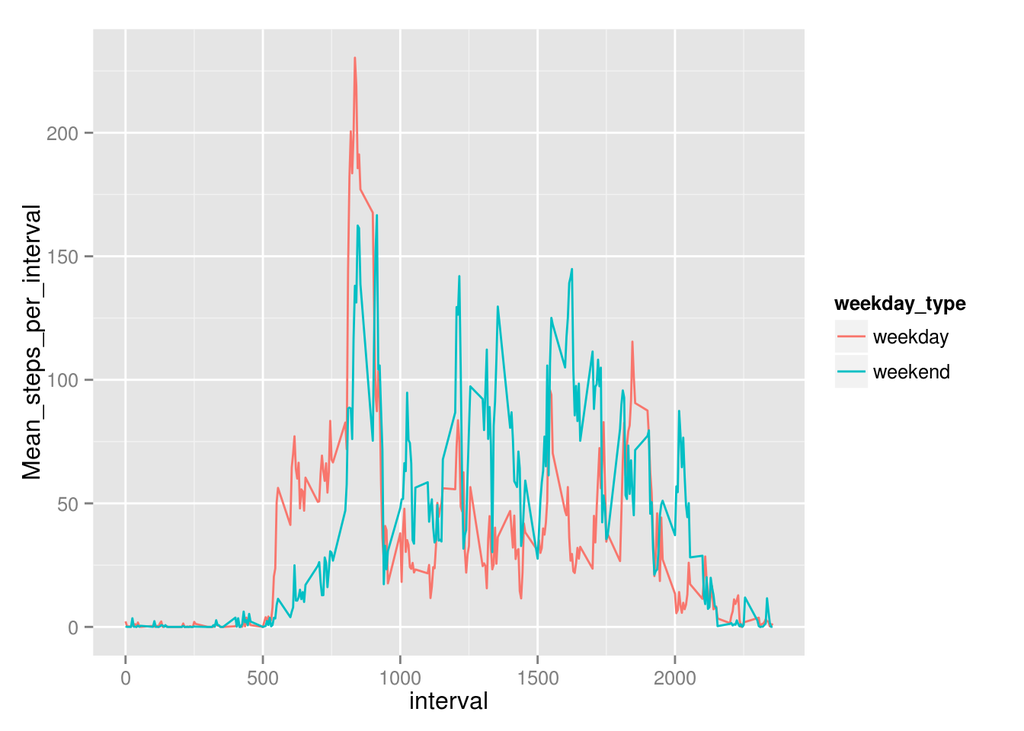

```r
Mean_steps_interval_weekday <- ddply(activity_imp, ~interval*weekday_type, summarize, Mean_steps_per_interval = mean(steps))
stepsinterval_weekday_plot <- ggplot(Mean_steps_interval_weekday, aes(x=interval, y=Mean_steps_per_interval, group=weekday_type, colour=weekday_type))
stepsinterval_weekday_plot + geom_line(stat ="identity")
```